# Presentacion del Dashboard

2024-07-22

## Introducción

El propósito de esta presentación es mostrar los hallazgos clave derivados de la encuesta sobre prioridades y sentimientos relacionados con los ingresos del hogar.

## Distribución de Sentimientos sobre los Ingresos del Hogar

Este gráfico de barras muestra cómo se distribuyen los sentimientos de los encuestados sobre sus ingresos actuales.

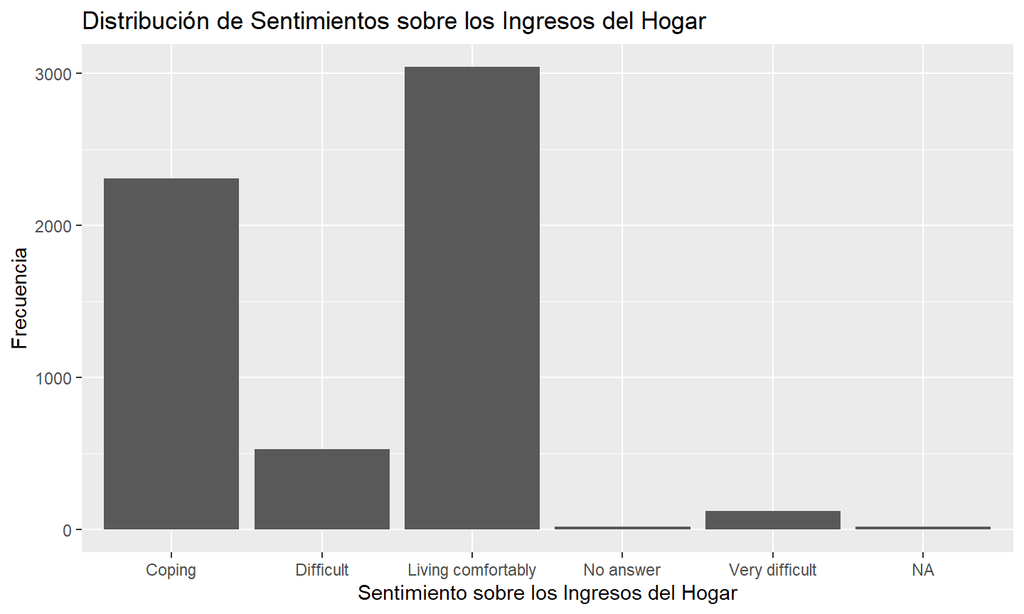

## Prioridad de Eliminar la Pobreza

Este gráfico de barras agrupadas muestra cómo los encuestados priorizan la eliminación de la pobreza, desglosado por su sentimiento sobre los ingresos.

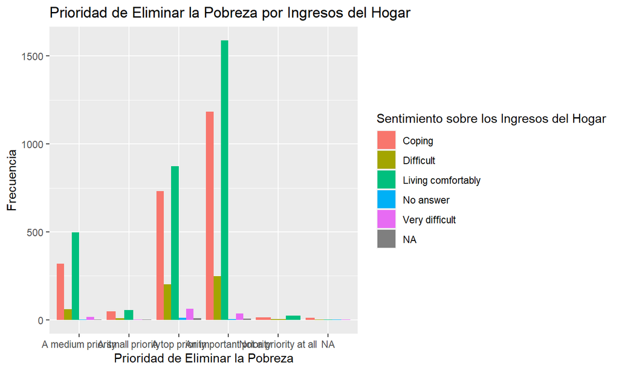

## Prioridad de Facilitar la Vida a las Familias

Este gráfico muestra la prioridad dada a facilitar la vida de las familias según el sentimiento sobre los ingresos.

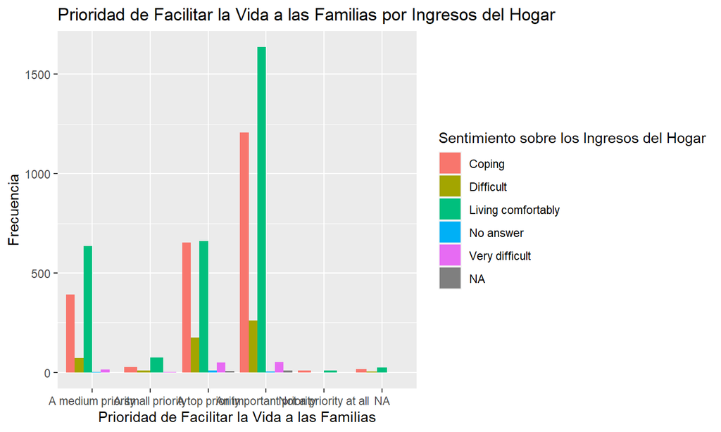

## Prioridad de Maximizar la Prosperidad Económica

Este gráfico ilustra cómo los encuestados priorizan la maximización de la prosperidad económica según su sentimiento sobre los ingresos.

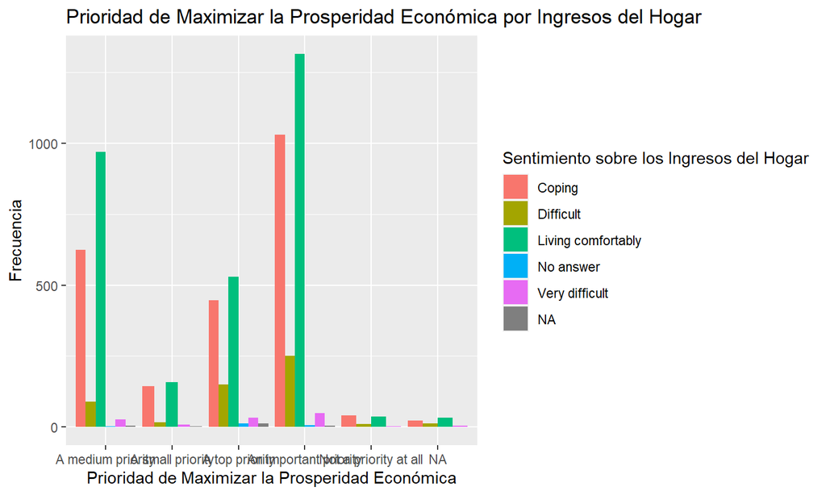

## Recomendaciones

- **Políticas de Apoyo**: Implementar políticas que aborden las dificultades económicas puede ser crucial para mejorar el bienestar general.
- **Facilitación de la Vida Familiar**: Las políticas que faciliten la vida de las familias deben ser priorizadas, ya que esto es una preocupación común entre los encuestados.
- **Prosperidad Económica**: Fomentar la prosperidad económica puede ayudar a aliviar algunas de las tensiones relacionadas con los ingresos del hogar.